# Exercise 3

Jacob John

Complete all **Exercises**, and submit answers to **VtopBeta**

## Question 1

Apply apriori algorithm to perform Market Basket Analysis Model for the following:

Given Dataset for question 1

| V1 | V2 | V3 | V4 | V5 | V6 | V7 |
| --- | --- | --- | --- | --- | --- | --- |
| T1 | M | O | N | K | E | Y |
| T2 | D | O | N | K | E | Y |
| T3 | M | A | K | E |  |  |
| T4 | M | U | C | K | Y |  |
| T5 | C | O | O | K | E |  |

Find the Association Rule using minimum support of 60% and minimum confidence of 80%.

```r
library(arules)
#Data Preprocessing
load("dataset.RData")
summary(dataset)
```

```
## transactions as itemMatrix in sparse format with
##  5 rows (elements/itemsets/transactions) and
##  10 columns (items) and a density of 0.5
##
## most frequent items:
##       K       E       M       O       Y (Other)
##       5       4       3       3       3       7
##
## element (itemset/transaction) length distribution:
## sizes
## 4 5 6
## 2 1 2
##
##    Min. 1st Qu.  Median    Mean 3rd Qu.    Max.
##       4       4       5       5       6       6
##
## includes extended item information - examples:
##   labels
## 1      A
## 2      C
## 3      D
##
## includes extended transaction information - examples:
##   transactionID
## 1            T1
## 2            T2
## 3            T3
```

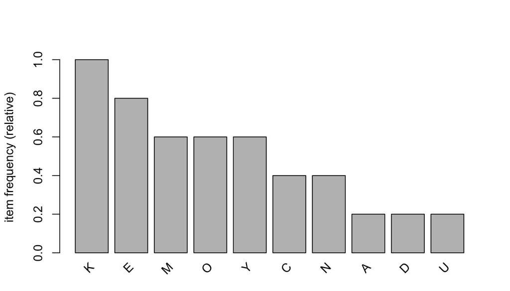

```r
itemFrequencyPlot(dataset,topN=10)
```

```r
#Apriori
rules <- apriori(data=dataset,parameter=list(support=0.60,confidence=0.80))
```

```
## Apriori
##
## Parameter specification:
##  confidence minval smax arem  aval originalSupport maxtime support minlen
##         0.8    0.1    1 none FALSE            TRUE       5     0.6      1
##  maxlen target   ext
##      10  rules FALSE
##
## Algorithmic control:
##  filter tree heap memopt load sort verbose
##     0.1 TRUE TRUE  FALSE TRUE    2    TRUE
##
## Absolute minimum support count: 3
##
## set item appearances ...[0 item(s)] done [0.00s].
## set transactions ...[10 item(s), 5 transaction(s)] done [0.00s].
## sorting and recoding items ... [5 item(s)] done [0.00s].
## creating transaction tree ... done [0.00s].
## checking subsets of size 1 2 3 done [0.00s].
## writing ... [10 rule(s)] done [0.00s].
## creating S4 object  ... done [0.00s].
```

```r
summary(rules)
```

```
## set of 10 rules
##
## rule length distribution (lhs + rhs):sizes
## 1 2 3
## 2 6 2
##
##    Min. 1st Qu.  Median    Mean 3rd Qu.    Max.
##       1       2       2       2       2       3
##
## summary of quality measures:
##     support      confidence        lift          count
##  Min.   :0.6   Min.   :0.80   Min.   :1.00   Min.   :3.0
##  1st Qu.:0.6   1st Qu.:1.00   1st Qu.:1.00   1st Qu.:3.0
##  Median :0.6   Median :1.00   Median :1.00   Median :3.0
##  Mean   :0.7   Mean   :0.96   Mean   :1.05   Mean   :3.5
##  3rd Qu.:0.8   3rd Qu.:1.00   3rd Qu.:1.00   3rd Qu.:4.0
##  Max.   :1.0   Max.   :1.00   Max.   :1.25   Max.   :5.0
##
## mining info:
##     data ntransactions support confidence
##  dataset             5     0.6        0.8
```

```r
#Data Visualization
inspect(sort(rules,by='lift')[1:10])
```

```
##      lhs      rhs support confidence lift count
## [1]  {O}   => {E} 0.6     1.0        1.25 3
## [2]  {K,O} => {E} 0.6     1.0        1.25 3
## [3]  {}    => {E} 0.8     0.8        1.00 4
## [4]  {}    => {K} 1.0     1.0        1.00 5
## [5]  {M}   => {K} 0.6     1.0        1.00 3
## [6]  {O}   => {K} 0.6     1.0        1.00 3
## [7]  {Y}   => {K} 0.6     1.0        1.00 3
## [8]  {E}   => {K} 0.8     1.0        1.00 4
## [9]  {K}   => {E} 0.8     0.8        1.00 4
## [10] {E,O} => {K} 0.6     1.0        1.00 3
```

## Question 2

Create a dataset with minimum 30 transactions with the purchase list of combination made out of 10 Items. Apply Apriori Algorithm to generate the association rule with

### a) Minimum confidence – 50% and Minimum support -50%

#### Inference:

Since the data set doesn’t allow for a minimum support of 0.5, a minimum support of 0.005 has been used. This is prevent any errors produced in the ouput.

```r
library(arules)
#Data Preprocessing
load("dataset2.RData")
summary(dataset)
```

```
## transactions as itemMatrix in sparse format with
##  7501 rows (elements/itemsets/transactions) and
##  119 columns (items) and a density of 0.03288973
##
## most frequent items:
## mineral water          eggs     spaghetti  french fries     chocolate
##          1788          1348          1306          1282          1229
##       (Other)
##         22405
##
## element (itemset/transaction) length distribution:
## sizes
##    1    2    3    4    5    6    7    8    9   10   11   12   13   14   15
## 1754 1358 1044  816  667  493  391  324  259  139  102   67   40   22   17
##   16   18   19   20
##    4    1    2    1
##
##    Min. 1st Qu.  Median    Mean 3rd Qu.    Max.
##   1.000   2.000   3.000   3.914   5.000  20.000
##
## includes extended item information - examples:
##              labels
## 1           almonds
## 2 antioxydant juice
## 3         asparagus
```

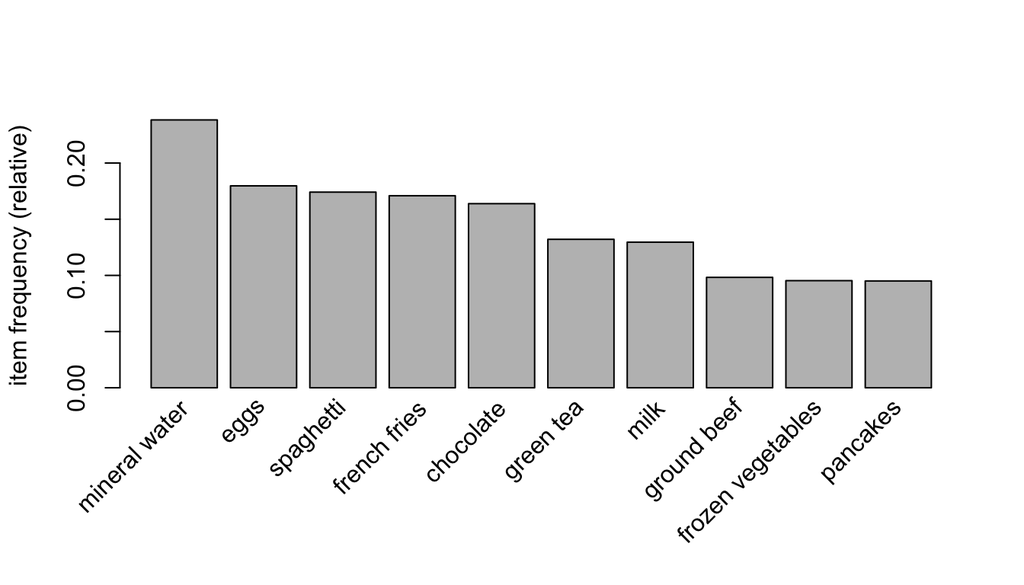

```r
itemFrequencyPlot(dataset, topN = 10)
```

```r
# Training Apriori on the dataset
rules = apriori(data = dataset, parameter = list(support = 0.005, confidence = 0.5))
```

```
## Apriori
##
## Parameter specification:
##  confidence minval smax arem  aval originalSupport maxtime support minlen
##         0.5    0.1    1 none FALSE            TRUE       5   0.005      1
##  maxlen target   ext
##      10  rules FALSE
##
## Algorithmic control:
##  filter tree heap memopt load sort verbose
##     0.1 TRUE TRUE  FALSE TRUE    2    TRUE
##
## Absolute minimum support count: 37
##
## set item appearances ...[0 item(s)] done [0.00s].
## set transactions ...[119 item(s), 7501 transaction(s)] done [0.00s].
## sorting and recoding items ... [101 item(s)] done [0.00s].
## creating transaction tree ... done [0.00s].
## checking subsets of size 1 2 3 4 done [0.00s].
## writing ... [20 rule(s)] done [0.00s].
## creating S4 object  ... done [0.00s].
```

```r
# Visualising the results
inspect(sort(rules, by = 'lift')[1:10])
```

```
##      lhs                                rhs             support
## [1]  {ground beef,shrimp}            => {spaghetti}     0.005999200
## [2]  {frozen vegetables,ground beef} => {spaghetti}     0.008665511
## [3]  {frozen vegetables,olive oil}   => {spaghetti}     0.005732569
## [4]  {frozen vegetables,soup}        => {mineral water} 0.005065991
## [5]  {olive oil,soup}                => {mineral water} 0.005199307
## [6]  {frozen vegetables,olive oil}   => {mineral water} 0.006532462
## [7]  {milk,soup}                     => {mineral water} 0.008532196
## [8]  {chocolate,soup}                => {mineral water} 0.005599253
## [9]  {cooking oil,eggs}              => {mineral water} 0.006399147
## [10] {frozen vegetables,ground beef} => {mineral water} 0.009198773
##      confidence lift     count
## [1]  0.5232558  3.005315 45
## [2]  0.5118110  2.939582 65
## [3]  0.5058824  2.905531 43
## [4]  0.6333333  2.656954 38
## [5]  0.5820896  2.441976 39
## [6]  0.5764706  2.418404 49
## [7]  0.5614035  2.355194 64
## [8]  0.5526316  2.318395 42
## [9]  0.5454545  2.288286 48
## [10] 0.5433071  2.279277 69
```

### b) Minimum confidence – 20% and Minimum support -80%

#### Inference:

Since the data set doesn’t allow for a minimum support of 0.8, a minimum support of 0.008 has been used. This is prevent any errors produced in the ouput.

```r
library(arules)
#Data Preprocessing
load("dataset2.RData")

# Training Apriori on the dataset
rules = apriori(data = dataset, parameter = list(support = 0.008, confidence = 0.2))
```

```
## Apriori
##
## Parameter specification:
##  confidence minval smax arem  aval originalSupport maxtime support minlen
##         0.2    0.1    1 none FALSE            TRUE       5   0.008      1
##  maxlen target   ext
##      10  rules FALSE
##
## Algorithmic control:
##  filter tree heap memopt load sort verbose
##     0.1 TRUE TRUE  FALSE TRUE    2    TRUE
##
## Absolute minimum support count: 60
##
## set item appearances ...[0 item(s)] done [0.00s].
## set transactions ...[119 item(s), 7501 transaction(s)] done [0.00s].
## sorting and recoding items ... [88 item(s)] done [0.00s].
## creating transaction tree ... done [0.01s].
## checking subsets of size 1 2 3 4 done [0.00s].
## writing ... [237 rule(s)] done [0.00s].
## creating S4 object  ... done [0.00s].
```

```r
# Visualising the results
inspect(sort(rules, by = 'lift')[1:10])
```

```
##      lhs                                  rhs           support
## [1]  {herb & pepper}                   => {ground beef} 0.015997867
## [2]  {frozen vegetables,spaghetti}     => {ground beef} 0.008665511
## [3]  {frozen vegetables,ground beef}   => {spaghetti}   0.008665511
## [4]  {mineral water,spaghetti}         => {ground beef} 0.017064391
## [5]  {eggs,french fries}               => {burgers}     0.009065458
## [6]  {mineral water,soup}              => {milk}        0.008532196
## [7]  {milk,spaghetti}                  => {ground beef} 0.009732036
## [8]  {frozen vegetables,mineral water} => {ground beef} 0.009198773
## [9]  {whole wheat pasta}               => {milk}        0.009865351
## [10] {eggs,ground beef}                => {spaghetti}   0.008932142
##      confidence lift     count
## [1]  0.3234501  3.291994 120
## [2]  0.3110048  3.165328  65
## [3]  0.5118110  2.939582  65
## [4]  0.2857143  2.907928 128
## [5]  0.2490842  2.856852  68
## [6]  0.3699422  2.854873  64
## [7]  0.2744361  2.793141  73
## [8]  0.2574627  2.620390  69
## [9]  0.3348416  2.583999  74
## [10] 0.4466667  2.565426  67
```

### c) Minimum confidence – 80% and Minimum support -20%

#### Inference:

Since the data set doesn’t allow for a minimum support and confidence of 0.2 and 0.8, respectively. A minimum support of 0.002 and a minimum confidence of 0.6 has been used. This is prevent any errors produced in the ouput.

```r
library(arules)
#Data Preprocessing
load("dataset2.RData")

#Apriori
rules <- apriori(data=dataset,parameter=list(support=0.002,confidence=0.6))
```

```
## Apriori
##
## Parameter specification:
##  confidence minval smax arem  aval originalSupport maxtime support minlen
##         0.6    0.1    1 none FALSE            TRUE       5   0.002      1
##  maxlen target   ext
##      10  rules FALSE
##
## Algorithmic control:
##  filter tree heap memopt load sort verbose
##     0.1 TRUE TRUE  FALSE TRUE    2    TRUE
##
## Absolute minimum support count: 15
##
## set item appearances ...[0 item(s)] done [0.00s].
## set transactions ...[119 item(s), 7501 transaction(s)] done [0.00s].
## sorting and recoding items ... [115 item(s)] done [0.00s].
## creating transaction tree ... done [0.00s].
## checking subsets of size 1 2 3 4 5 done [0.00s].
## writing ... [43 rule(s)] done [0.00s].
## creating S4 object  ... done [0.00s].
```

```r
summary(rules)
```

```
## set of 43 rules
##
## rule length distribution (lhs + rhs):sizes
##  3  4
## 16 27
##
##    Min. 1st Qu.  Median    Mean 3rd Qu.    Max.
##   3.000   3.000   4.000   3.628   4.000   4.000
##
## summary of quality measures:
##     support           confidence          lift            count
##  Min.   :0.002133   Min.   :0.6000   Min.   : 2.517   Min.   :16.00
##  1st Qu.:0.002200   1st Qu.:0.6180   1st Qu.: 2.637   1st Qu.:16.50
##  Median :0.002400   Median :0.6400   Median : 2.743   Median :18.00
##  Mean   :0.002713   Mean   :0.6643   Mean   : 3.315   Mean   :20.35
##  3rd Qu.:0.003066   3rd Qu.:0.6972   3rd Qu.: 3.344   3rd Qu.:23.00
##  Max.   :0.005066   Max.   :0.9500   Max.   :11.976   Max.   :38.00
##
## mining info:
##     data ntransactions support confidence
##  dataset          7501   0.002        0.6
```

```r
#Data Visualization
inspect(sort(rules,by='lift')[1:10])
```

```
##      lhs                       rhs                     support confidence      lift count
## [1]  {mushroom cream sauce,
##       pasta}                => {escalope}          0.002532996  0.9500000 11.976387    19
## [2]  {parmesan cheese,
##       tomatoes}             => {frozen vegetables} 0.002133049  0.6666667  6.993939    16
## [3]  {frozen vegetables,
##       olive oil,
##       tomatoes}             => {spaghetti}         0.002133049  0.8421053  4.836624    16
## [4]  {frozen vegetables,
##       mineral water,
##       soup}                 => {milk}              0.003066258  0.6052632  4.670863    23
## [5]  {frozen vegetables,
##       ground beef,
##       shrimp}               => {spaghetti}         0.002399680  0.7500000  4.307619    18
## [6]  {cereals,
##       ground beef}          => {spaghetti}         0.003066258  0.6764706  3.885303    23
## [7]  {cooking oil,
##       ground beef,
##       mineral water}        => {spaghetti}         0.002133049  0.6666667  3.828994    16
## [8]  {frozen vegetables,
##       ground beef,
##       olive oil}            => {spaghetti}         0.002133049  0.6400000  3.675835    16
## [9]  {french wine,
##       ground beef}          => {spaghetti}         0.002399680  0.6206897  3.564926    18
## [10] {olive oil,
##       tomatoes}             => {spaghetti}         0.004399413  0.6111111  3.509912    33
```